# R語言建構配對交易策略與回測

周育呈

2023-10-18

# 1. 前言

配對交易是一上盈課老師$\color{red}{\bf資產管理}$的小組報告，那時候為了期末報告有寫過一次配對交易回測了，但那時候還不太熟悉R語言，  
且後來發現當時回測邏輯犯了前視偏誤(Look-ahead bias)；所以打算重新寫，這次加入了老師的建議，還有一些當時來不及寫進回測的想法，於是有了這一篇pair_project。  
先說結論：現實中基本上不可行，風險太大，雖然有賺有賠但互抵後應該還是負報酬，但可以做為Prototype，改善想法詳情請見$\bf6.2 建議$。

# 2. 交易邏輯

資料來源為TEJ，抓取：$\color{red}{TEJ股價資料庫}$ $\to$ $\color{red}{未調整股價(日)-均價}$ 中的 $\color{blue}{收盤價(元)、當日均價(元)}$  
碩一上是以收盤價檢測進退場，隔日開盤價作為交易標準，盈課教授建議以日均價計算報酬率較為貼近現實，因此改為日均價計算報酬率

## 2.1 配對篩選

1. 首先把TEJ股價資料去除NA值，抓出資料長度一樣的公司，也就是在資料時程中有完整股價的個股，否則無法計算相關係數和迴歸。
2. 接著把資料時間分為$估計期_e$和$交易期_r$，把估計期股票收盤價兩兩組和計算相關係數，定義通關相關係數標準的$Pair$一股為Y股、一股為X股，$Y_e$股對$X_e$股收盤價去跑簡迴歸($OLS : Y_e = \hat{\alpha}_e+\hat{\beta}_e*X_e+\epsilon_e$)取得迴歸殘差($\epsilon_e$)。
3. 把殘差($\epsilon_e$)拿去跑定態檢定($Augmented \quad Dickey–Fuller \quad test$)，通過定態檢定後則成為配對樣本，準備交易。

## 2.2 交易原則

首先透過配對樣本迴歸的截距($\hat{\alpha}_e$)和係數($\hat{\beta}_e$)和兩股交易期收盤價($Y_r、X_r$)計算得出交易期的$ResidualPath(\epsilon_r)$
$$ResidualPath(\epsilon_r) = Y_r - \hat{\alpha}_e -
\hat{\beta}_e\ast X_r$$
再計算估計期殘差的平均數、標準差
$$mean(\epsilon_e) 、 sd(\epsilon_e)$$
都計算完後，設定估計期殘差($\epsilon_e$)的平均數加減a倍標準差為建倉標準、b倍為平倉標準、c倍為停損標準，例如：
$$建倉標準:mean(\epsilon_e) \pm 2 \ast
sd(\epsilon_e)$$
$$平倉標準:mean(\epsilon_e) \pm 1 \ast
sd(\epsilon_e)$$
$$停損標準:mean(\epsilon_e) \pm 5 \ast
sd(\epsilon_e)$$
之後開始逐日檢測進場訊號，假如當$t$日達到進場標準
$$ResidualPath(\epsilon_r) \ge mean(\epsilon_e) + 2
\ast sd(\epsilon_e)$$
此時$\epsilon_r$達到擴張進場訊號，也就是兩股股價差距變大導致$\epsilon_r$變大，超過設定之進場標準，於是以隔日($t+1$)均價放空$Y_r$股買進$X_r$股，且以多空兩部位相等價值去做交易。
接著($t+2$)逐日檢測退場訊號，當$h$日到退場標準
$$ResidualPath(\epsilon_r) \le mean(\epsilon_e) + 1
\ast sd(\epsilon_e)\quad or \quad ResidualPath(\epsilon_r) \ge
mean(\epsilon_e) + 5 \ast sd(\epsilon_e)$$
此時$\epsilon_r$達到退場訊號，也就是兩股股價差距變小導致$\epsilon_r$變小(或者差距更加擴大導致$\epsilon_r$變更大)，超過設定之退場標準(平倉或停損)，於是以隔日($h+1$)均價回補$Y_r$股賣出$X_r$股，清空所有部位，結束交易。交易過程視覺化後如下圖：

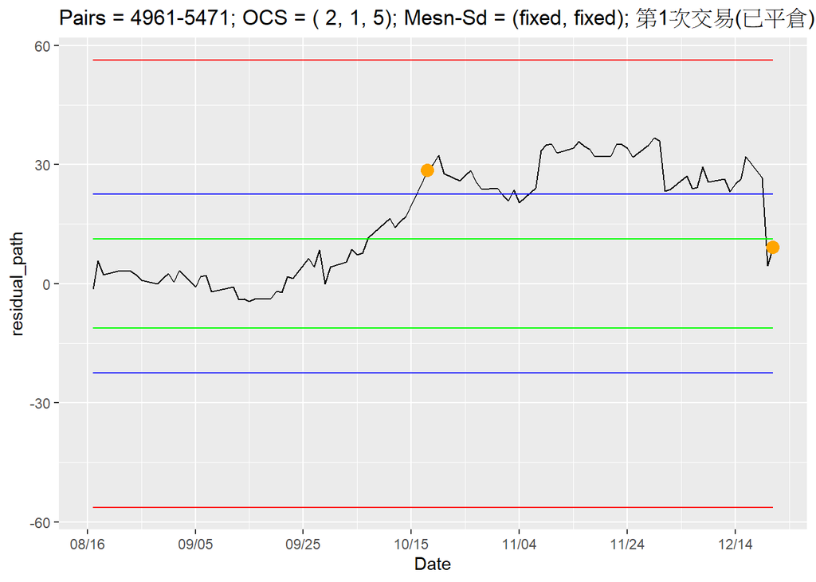

- 在逐日檢測進場訊號時，只有$ResidualPath(\epsilon_r) \le mean(\epsilon_e) + 5 \ast sd(\epsilon_e)$才會進場，如果還未進場但$\epsilon_r$已大於停損標準，則直接跳過當日，隔日繼續檢測進場訊號，避免在以達停損條件下進場，隔日直接出場(結束交易)的情況，也就是建倉後馬上停損結束交易。
- 上述舉例為擴張交易，把$\ge$改為$\le$則為收縮交易，交易邏輯一致只是交易時多空部位反過來做。
- 交易邏輯簡單來說就是：找出估計期的共整合關係($Cointegration$)，$\color{red}{單純}$的相信未來共整合關係會持續存在。

# 3. Arguments

我寫了一個函數pair_trade()，輸入符合的資料格式後，就能以上述的交易邏輯，自己選擇配對交易的各種策略標準，跑出交易內容，這節講解各個argument的作用及如何使用。

## 3.1 TEJ_data

輸入股價資料，格式需為5個colunms，需依序為股票代號、股票名稱、日期(需為年月日)、收盤價、日均價或開盤價(看要以哪個價格做交易)，如資料來源跟我一樣為TEJ，則不需要再清洗資料。  
範例資料:

| 代號 | 名稱 | 日期 | 收盤價(元) | 當日均價(元) |
| --- | --- | --- | --- | --- |
| 2302 | 麗正 | 2022/01/03 | 17.6 | 17.3129 |
| 2303 | 聯電 | 2022/01/03 | 63.4 | 63.8887 |
| 2329 | 華泰 | 2022/01/03 | 26.0 | 26.1362 |

## 3.2 estimate_days

輸入估計期天數，需輸入正整數且少於股價資料長度，如TEJ_data中個股資料天數為100天，則輸入< 100之數值。

## 3.3 corr_coef

輸入相關係數標準，需輸入 0 ~ 1 的數值。

## 3.4 ADF_p.value

輸入定態檢定(Augmented Dickey–Fuller test)的p.value數值，需輸入 0 ~ 1 的數值。

## 3.5 Open

輸入建倉標準，也就是滿足$mean(\epsilon_e) \pm \color{red}{Open} \ast sd(\epsilon_e)$建倉，需輸入> 0 的數值。

## 3.6 Close

輸入平倉標準，也就是滿足$mean(\epsilon_e) \pm \color{red}{Close} \ast sd(\epsilon_e)$平倉，需輸入> 0 的數值。

## 3.8 mean_type

輸入估計期殘差平均數：$mean(\epsilon_e)$計算方式，影響進退場標準，需輸入$'fixed' \quad or \quad 'rolling'$ 字串。  
fixed計算方式為一般平均數，rolling計算方式為滾動(移動)平均數。

## 3.9 sd_type

輸入估計期殘差標準差：$sd(\epsilon_e)$計算方式，影響進退場標準，需輸入$'fixed' \quad or \quad 'rolling'$ 字串。  
fixed計算方式為一般標準差，rolling計算方式為滾動(移動)標準差。

## 3.10 Windows

輸入計算滾動(移動)平均數、滾動(移動)標準差的窗期，需輸入正整數且少於估計期天數，也就是滿足Windows < estimate_days。

## 3.11 Weight

輸入進場時多空兩部位價值的權重，需輸入 $\bf equal$ or $\bf less$ or $\bf beta$ 字串。

1. $\bf equal$：把兩股均價四捨五入後取最小公倍數後，除以自身股價即為買入(放空)的股數，  
   $\bf equal$的好處是多空兩部位價值最接近，但可能導致購買的股數相當多。 範例資料：

   | 交易日期 | 交易型態 | 建or平倉 | 買入股 | 買入價 | 買入量 | 放空股 | 放空價 | 放空量 | 交易天數 | 報酬率% | 建倉成本(千) | 第n次交易 | corr_coef | Intercept | beta | p.value | adj.r.squared |
   | --- | --- | --- | --- | --- | --- | --- | --- | --- | --- | --- | --- | --- | --- | --- | --- | --- | --- |
   | 2022-11-22 | 擴張 | 建倉 | 買入 6719 | 262.4851 | 201 | 放空 6531 | 200.7417 | 262 | NA | NA | 100170 | 1 | 0.971478 | 58.50501 | 0.424707 | 0.01 | 0.9433896 |
   | 2022-12-02 | 擴張 | 平倉 | 回補 6531 | 208.4445 | 262 | 賣出 6719 | 310.4400 | 201 | 10 | 6.910619 | NA | 1 | NA | NA | NA | NA | NA |

2. $\bf less$：把兩股均價先取有效位數2位後取最小公倍數後，除以自身股價即為買入(放空)的股數，  
   $\bf less$的好處是有時能避免多空兩部位的數量過多，且兩部位價值也大致相等。  
   範例資料：

   | 交易日期 | 交易型態 | 建or平倉 | 買入股 | 買入價 | 買入量 | 放空股 | 放空價 | 放空量 | 交易天數 | 報酬率% | 建倉成本(千) | 第n次交易 | corr_coef | Intercept | beta | p.value | adj.r.squared |
   | --- | --- | --- | --- | --- | --- | --- | --- | --- | --- | --- | --- | --- | --- | --- | --- | --- | --- |
   | 2022-11-22 | 擴張 | 建倉 | 買入 6719 | 262.4851 | 10 | 放空 6531 | 200.7417 | 13 | NA | NA | 4977 | 1 | 0.971478 | 58.50501 | 0.424707 | 0.01 | 0.9433896 |
   | 2022-12-02 | 擴張 | 平倉 | 回補 6531 | 208.4445 | 13 | 賣出 6719 | 310.4400 | 10 | 10 | 6.925672 | NA | 1 | NA | NA | NA | NA | NA |

3. $\bf beta$：Y股一律交易10單位，Y股均價乘10再乘簡迴歸的係數($\hat{\beta}_e$)後除以X股均價即為X股交易單位，簡單來說就是Y股部位價值與X股部位價值成$1:\hat{\beta}_e$的比例，這是當初一位組員說在網路上看到的方法，我是不清楚這樣做的道理，但還是把它寫出來了。  
   範例資料：

   | 交易日期 | 交易型態 | 建or平倉 | 買入股 | 買入價 | 買入量 | 放空股 | 放空價 | 放空量 | 交易天數 | 報酬率% | 建倉成本(千) | 第n次交易 | corr_coef | Intercept | beta | p.value | adj.r.squared |
   | --- | --- | --- | --- | --- | --- | --- | --- | --- | --- | --- | --- | --- | --- | --- | --- | --- | --- |
   | 2022-11-22 | 擴張 | 建倉 | 買入 6719 | 262.4851 | 4 | 放空 6531 | 200.7417 | 10 | NA | NA | 2858 | 1 | 0.971478 | 58.50501 | 0.424707 | 0.01 | 0.9433896 |
   | 2022-12-02 | 擴張 | 平倉 | 回補 6531 | 208.4445 | 10 | 賣出 6719 | 310.4400 | 4 | 10 | 3.308127 | NA | 1 | NA | NA | NA | NA | NA |

## 3.12 Rebalance

輸入是否$Pair$要在一次完整交易後重新檢視它是否有符合樣本條件，如有符合條件則重新估計簡迴歸，也就是重新檢視兩股之間的關係，需輸入 $TRUE \quad or \quad FALSE$。

- 實際過程：假如有設定一組$Pair$估計期為100天，它的資料總長度為250天，在估計期後(交易期)的50天完成了第一次交易，也就是資料的150天完成交易，此時程式會從第150天往回抓100天為新估計期(第51天 ~ 第150天)，接著重複上述估計動作，通過了相關係數、定態檢定後則再次逐日(第151天開始)檢測進場標準，如同前次交易一樣(建倉、平倉、停損條件不變)，如任一標準沒通過則放棄該組$Pair$。

## 3.13 Plot_StopLoss

輸入是否在交易圖中畫停損線，如果策略中不想要有停損條件，可在argument：$\color{red}{StopLoss}$輸入一個極大值讓$\epsilon_r$不可能達到停損條件，但此時交易圖會因為停損線極大導致看不清其他資訊，此時可選擇圖不要畫上停損線，需輸入$TRUE \quad or \quad FALSE$。

# 4. Outputs

這節說明pair_trade()函數回傳的list裡有哪些內容，主要分成 Rebalance = TRUE 和 Rebalance = FALSE 來說明。

## 4.1 Rebalance = TRUE

也就是每完整交易一次後會重新估計。  
範例資料：example_true的argumeants如下

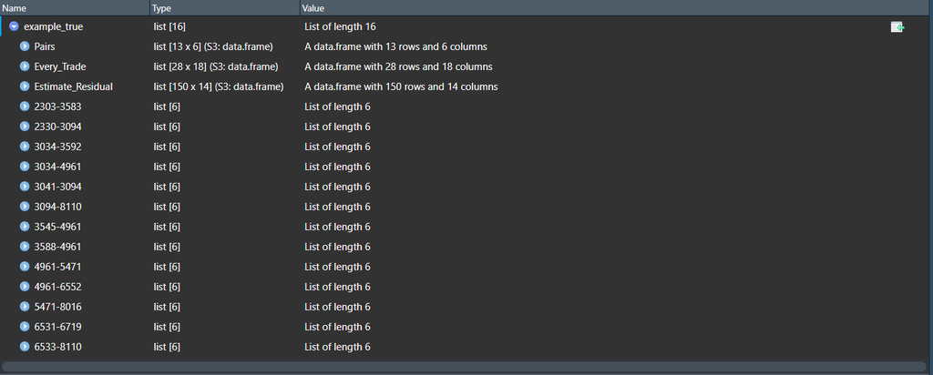

此圖為函數回傳的list檔案內容，在此條件下篩出了13組樣本

```r
example_true<- pair_trade(TEJ_data = semiconductor,
                               corr_coef = 0.95,estimate_days = 150,
                               ADF_p.value = 0.02,mean_type = "fixed",
                               sd_type = "fixed",Open = 2,Windows = 30,
                               Close = 1,Stop_loss = 5,Weight = "equal",Rebalance = TRUE,
                     Plot_StopLoss = TRUE)
```

可以看到list裡有：

- $Pairs:$裡包含了每組配對的交易資訊，有兩股代號、總交易次數、平均交易天數、所有交易的一般平均數報酬率、幾何平均數報酬率。

  | y_stock | x_stock | Transactions | Mean_Days | Return_AMean(%) | Return_GMean(%) |
  | --- | --- | --- | --- | --- | --- |
  | 2303 | 3583 | 1 | 41 | 2.7450408 | 2.7450408 |
  | 2330 | 3094 | 1 | 63 | -3.1422470 | -3.1422470 |
  | 3034 | 3592 | 1 | 119 | -11.3104199 | -11.3104199 |
  | 3034 | 4961 | 1 | 75 | 5.1361719 | 5.1361719 |
  | 3041 | 3094 | 1 | 116 | 0.4321787 | 0.4321787 |
  | 3094 | 8110 | 1 | 10 | 1.4799933 | 1.4799933 |
  | 3545 | 4961 | 1 | 96 | -12.7462151 | -12.7462151 |
  | 3588 | 4961 | 2 | 30 | -0.4631313 | -0.9992227 |
  | 4961 | 5471 | 1 | 64 | 7.3237163 | 7.3237163 |
  | 4961 | 6552 | 1 | 8 | 0.2885132 | 0.2885132 |
  | 5471 | 8016 | 1 | 55 | -8.9540719 | -8.9540719 |
  | 6531 | 6719 | 1 | 10 | 6.9106193 | 6.9106193 |
  | 6533 | 8110 | 1 | 12 | -8.1559465 | -8.1559465 |

- $Every-Trade:$裡包含了所有配對每次交易的資訊，也就是把下面各個配對裡的$List檔案內容$合併在一起而以，可以視為該交易策略的raw_data，可拿來跑些簡單的統計找最適合的交易策略，最後5個column為該次交易的相關係數、迴歸截距、迴歸係數、ADF test的p.value、迴歸的調整R_square。

  | 交易日期 | 交易型態 | 建or平倉 | 買入股 | 買入價 | 買入量 | 放空股 | 放空價 | 放空量 | 交易天數 | 報酬率% | 建倉成本(千) | 第n次交易 | corr_coef | Intercept | beta | p.value | adj.r.squared |
  | --- | --- | --- | --- | --- | --- | --- | --- | --- | --- | --- | --- | --- | --- | --- | --- | --- | --- |
  | 2022-08-19 | 收縮 | 建倉 | 買入 2303 | 42.8692 | 85 | 放空 3583 | 85.0050 | 43 | NA | NA | 8895 | 1 | 0.9524233 | -5.435804 | 0.6487381 | 0.0140178 | 0.9064825 |
  | 2022-09-29 | 收縮 | 平倉 | 回補 3583 | 67.3529 | 43 | 賣出 2303 | 36.6584 | 85 | 41 | 2.7450408 | NA | 1 | NA | NA | NA | NA | NA |
  | 2022-09-05 | 收縮 | 建倉 | 買入 2330 | 485.9129 | 29 | 放空 3094 | 29.4355 | 486 | NA | NA | 213393 | 1 | 0.9527771 | 148.433832 | 12.9443124 | 0.0100000 | 0.9071611 |
  | 2022-11-07 | 收縮 | 停損 | 回補 3094 | 25.1512 | 486 | 賣出 2330 | 390.1473 | 29 | 63 | -3.1422470 | NA | 1 | NA | NA | NA | NA | NA |
  | 2023-02-09 | 擴張 | 建倉 | 買入 3592 | 379.5814 | 193 | 放空 3034 | 385.5223 | 190 | NA | NA | 139288 | 1 | 0.9512304 | 90.228995 | 0.6373223 | 0.0130521 | 0.9041962 |
  | 2023-06-08 | 擴張 | 停損 | 回補 3034 | 453.2438 | 190 | 賣出 3592 | 368.9465 | 193 | 119 | -11.3104199 | NA | 1 | NA | NA | NA | NA | NA |
  | 2022-12-08 | 擴張 | 建倉 | 買入 4961 | 118.9282 | 298 | 放空 3034 | 298.3775 | 119 | NA | NA | 67447 | 1 | 0.9585993 | 11.334541 | 2.0692212 | 0.0108484 | 0.9183647 |
  | 2023-02-21 | 擴張 | 平倉 | 回補 3034 | 420.1439 | 119 | 賣出 4961 | 180.9168 | 298 | 75 | 5.1361719 | NA | 1 | NA | NA | NA | NA | NA |
  | 2022-08-19 | 收縮 | 建倉 | 買入 3041 | 25.6309 | 15 | 放空 3094 | 30.3274 | 13 | NA | NA | 755 | 1 | 0.9595573 | -4.813853 | 1.1032537 | 0.0148592 | 0.9202147 |
  | 2022-12-13 | 收縮 | 平倉 | 回補 3094 | 25.3203 | 13 | 賣出 3041 | 21.7744 | 15 | 116 | 0.4321787 | NA | 1 | NA | NA | NA | NA | NA |
  | 2022-08-19 | 擴張 | 建倉 | 買入 8110 | 13.2882 | 30 | 放空 3094 | 30.3274 | 13 | NA | NA | 754 | 1 | 0.9535481 | 2.084362 | 1.9419145 | 0.0100000 | 0.9086409 |
  | 2022-08-29 | 擴張 | 平倉 | 回補 3094 | 28.8285 | 13 | 賣出 8110 | 13.1730 | 30 | 10 | 1.4799933 | NA | 1 | NA | NA | NA | NA | NA |
  | 2022-11-16 | 收縮 | 建倉 | 買入 3545 | 67.4844 | 129 | 放空 4961 | 129.1162 | 67 | NA | NA | 20749 | 1 | 0.9707261 | -9.350922 | 0.7186792 | 0.0100000 | 0.9419194 |
  | 2023-02-20 | 收縮 | 停損 | 回補 4961 | 172.3540 | 67 | 賣出 3545 | 74.4712 | 129 | 96 | -12.7462151 | NA | 1 | NA | NA | NA | NA | NA |
  | 2022-10-18 | 收縮 | 建倉 | 買入 3588 | 47.7311 | 55 | 放空 4961 | 110.4359 | 24 | NA | NA | 7114 | 1 | 0.9550469 | -6.292089 | 0.6485530 | 0.0103500 | 0.9115208 |
  | 2022-10-31 | 收縮 | 平倉 | 回補 4961 | 104.6564 | 24 | 賣出 3588 | 54.8136 | 55 | 13 | 9.8535698 | NA | 1 | NA | NA | NA | NA | NA |
  | 2023-01-04 | 收縮 | 建倉 | 買入 3588 | 55.2881 | 25 | 放空 4961 | 124.9587 | 11 | NA | NA | 3676 | 2 | 0.9740933 | -22.466359 | 0.7353974 | 0.0100000 | 0.9485121 |
  | 2023-02-20 | 收縮 | 停損 | 回補 4961 | 172.3540 | 11 | 賣出 3588 | 65.5768 | 25 | 47 | -10.7798324 | NA | 2 | NA | NA | NA | NA | NA |
  | 2022-10-18 | 擴張 | 建倉 | 買入 5471 | 46.7860 | 110 | 放空 4961 | 110.4359 | 47 | NA | NA | 9825 | 1 | 0.9549251 | -73.721639 | 3.3440036 | 0.0100000 | 0.9112865 |
  | 2022-12-21 | 擴張 | 平倉 | 回補 4961 | 114.8429 | 47 | 賣出 5471 | 55.8093 | 110 | 64 | 7.3237163 | NA | 1 | NA | NA | NA | NA | NA |
  | 2022-08-31 | 收縮 | 建倉 | 買入 4961 | 125.9732 | 1 | 放空 6552 | 41.9966 | 3 | NA | NA | 382 | 1 | 0.9627072 | -143.622204 | 6.9920129 | 0.0100000 | 0.9263105 |
  | 2022-09-08 | 收縮 | 平倉 | 回補 6552 | 37.7505 | 3 | 賣出 4961 | 115.4255 | 1 | 8 | 0.2885132 | NA | 1 | NA | NA | NA | NA | NA |
  | 2022-08-24 | 收縮 | 建倉 | 買入 5471 | 58.4263 | 187 | 放空 8016 | 187.2221 | 58 | NA | NA | 38110 | 1 | 0.9656620 | 25.020045 | 0.2077351 | 0.0100000 | 0.9320470 |
  | 2022-10-18 | 收縮 | 停損 | 回補 8016 | 179.6078 | 58 | 賣出 5471 | 46.7860 | 187 | 55 | -8.9540719 | NA | 1 | NA | NA | NA | NA | NA |
  | 2022-11-22 | 擴張 | 建倉 | 買入 6719 | 262.4851 | 201 | 放空 6531 | 200.7417 | 262 | NA | NA | 100170 | 1 | 0.9714780 | 58.505013 | 0.4247070 | 0.0100000 | 0.9433896 |
  | 2022-12-02 | 擴張 | 平倉 | 回補 6531 | 208.4445 | 262 | 賣出 6719 | 310.4400 | 201 | 10 | 6.9106193 | NA | 1 | NA | NA | NA | NA | NA |
  | 2022-08-18 | 擴張 | 建倉 | 買入 8110 | 12.9778 | 322 | 放空 6533 | 321.9414 | 13 | NA | NA | 7952 | 1 | 0.9710411 | -157.174048 | 33.4874905 | 0.0100000 | 0.9425351 |
  | 2022-08-30 | 擴張 | 停損 | 回補 6533 | 375.7028 | 13 | 賣出 8110 | 13.2995 | 322 | 12 | -8.1559465 | NA | 1 | NA | NA | NA | NA | NA |

- $Estimate.Residual:$裡包含了每個配對第一次估計迴歸的殘差(也就是$\epsilon_e$)，沒有特別的意義只是計算過程，單純是在跑程式的時候存下來的。

  | Date | 2303-3583 | 2330-3094 | 3034-3592 | 3034-4961 | 3041-3094 | 3094-8110 | 3545-4961 | 3588-4961 | 4961-5471 | 4961-6552 | 5471-8016 | 6531-6719 | 6533-8110 |
  | --- | --- | --- | --- | --- | --- | --- | --- | --- | --- | --- | --- | --- | --- |
  | 2022-01-03 | -0.5791749 | -83.10029 | 78.12405 | -57.8895338 | -2.2483343 | 5.593124 | -17.175960 | -25.92413 | 38.54129 | 35.268681 | 3.2969833 | 37.58691 | 62.98110 |
  | 2022-01-04 | -0.9791749 | -43.86154 | 79.13460 | -63.8895338 | -1.9347552 | 5.172794 | -21.175960 | -26.92413 | 42.21970 | 36.667083 | 3.0279238 | 44.58105 | 70.70172 |
  | 2022-01-05 | 4.1809825 | -41.44774 | 78.60640 | -34.5051095 | -1.9676403 | 4.716985 | -11.802375 | -19.45307 | 23.55730 | 20.862291 | 4.9130100 | 44.60224 | 66.05047 |
  | 2022-01-06 | 0.0183014 | -33.85621 | 80.70498 | -11.6398444 | -0.8092239 | 3.764081 | -7.318885 | -15.84616 | 13.73250 | 13.256700 | 3.8014073 | 24.87636 | 48.72484 |
  | 2022-01-07 | 2.8376229 | -19.26202 | 81.53946 | -0.9476322 | -0.8630418 | 2.835038 | -4.132093 | -13.86063 | 10.08611 | 6.053505 | 3.4594207 | 27.96112 | 34.46859 |
  | 2022-01-10 | -4.1497583 | -31.62013 | 65.41979 | -9.3283489 | -1.5834105 | 4.387943 | -3.584828 | -15.42767 | 22.27412 | 13.651109 | 0.0052749 | 37.38583 | 36.79422 |

  Note:

  只show前面幾筆，不然這檔案會太大，總共有13組配對樣本
- $\bf各組配對:$以3588-4961為例，此組有交易兩次。

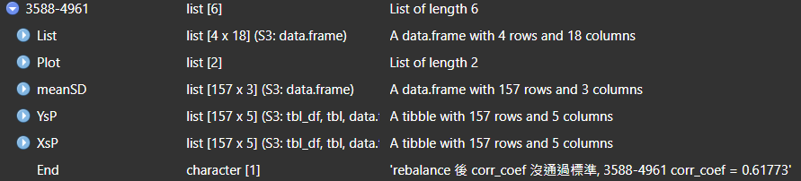

  包含了交易資訊、交易圖、每日對應的殘差平均數和標準差、兩股股價資料、此配對結束原因

  可以看到配對樣本裡有：
  - $List:$交易資訊，資料如同Every_Trade裡的資料。

    | 交易日期 | 交易型態 | 建or平倉 | 買入股 | 買入價 | 買入量 | 放空股 | 放空價 | 放空量 | 交易天數 | 報酬率% | 建倉成本(千) | 第n次交易 | corr_coef | Intercept | beta | p.value | adj.r.squared |
    | --- | --- | --- | --- | --- | --- | --- | --- | --- | --- | --- | --- | --- | --- | --- | --- | --- | --- |
    | 2022-10-18 | 收縮 | 建倉 | 買入 3588 | 47.7311 | 55 | 放空 4961 | 110.4359 | 24 | NA | NA | 7114 | 1 | 0.9550469 | -6.292089 | 0.6485530 | 0.01035 | 0.9115208 |
    | 2022-10-31 | 收縮 | 平倉 | 回補 4961 | 104.6564 | 24 | 賣出 3588 | 54.8136 | 55 | 13 | 9.85357 | NA | 1 | NA | NA | NA | NA | NA |
    | 2023-01-04 | 收縮 | 建倉 | 買入 3588 | 55.2881 | 25 | 放空 4961 | 124.9587 | 11 | NA | NA | 3676 | 2 | 0.9740933 | -22.466359 | 0.7353974 | 0.01000 | 0.9485121 |
    | 2023-02-20 | 收縮 | 停損 | 回補 4961 | 172.3540 | 11 | 賣出 3588 | 65.5768 | 25 | 47 | -10.77983 | NA | 2 | NA | NA | NA | NA | NA |

  - $Plot:$交易圖，標題有股票代碼、建倉平倉停損的標準差倍數，$mean(\epsilon)、sd(\epsilon)$的計算方式、第幾次交易的圖及最終狀態，最終狀態有：已平倉、未平倉、未建倉等。

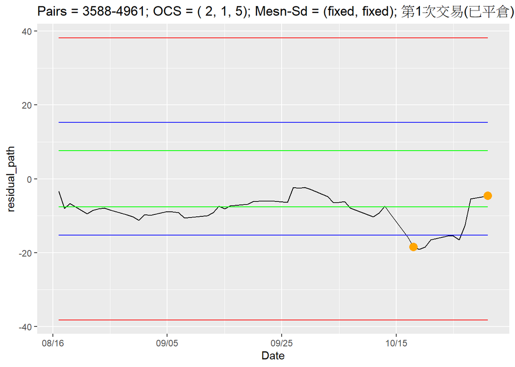

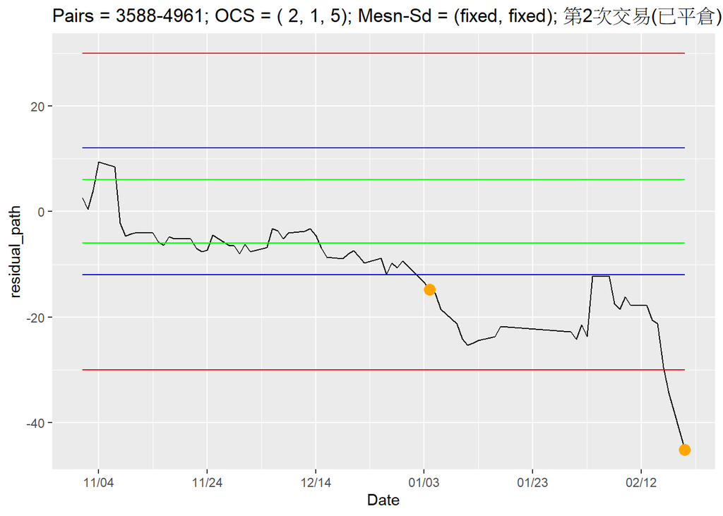

- $meanSD:$每日對應的殘差平均數和標準差，只show前面幾筆，不然這檔案會太大，此範例資料為fixed、fixed，所以值都一樣不變(不滾動計算)。

  | Date | mean_col | sd_col |
  | --- | --- | --- |
  | 2022-11-01 | 0 | 6.004936 |
  | 2022-11-02 | 0 | 6.004936 |
  | 2022-11-03 | 0 | 6.004936 |
  | 2022-11-04 | 0 | 6.004936 |
  | 2022-11-07 | 0 | 6.004936 |
  | 2022-11-08 | 0 | 6.004936 |

- $YsP:$Y股股價資料，只show前面幾筆，不然這檔案會太大。

  | Stock | Name | Date | CloPr | AvePr |
  | --- | --- | --- | --- | --- |
  | 3588 | 通嘉 | 2022-11-01 | 56.2 | 56.4135 |
  | 3588 | 通嘉 | 2022-11-02 | 55.6 | 55.8756 |
  | 3588 | 通嘉 | 2022-11-03 | 61.1 | 59.4234 |
  | 3588 | 通嘉 | 2022-11-04 | 65.3 | 66.0928 |
  | 3588 | 通嘉 | 2022-11-07 | 66.9 | 66.1948 |
  | 3588 | 通嘉 | 2022-11-08 | 64.3 | 65.5129 |

- $XsP:$X股股價資料，只show前面幾筆，不然這檔案會太大。

  | Stock | Name | Date | CloPr | AvePr |
  | --- | --- | --- | --- | --- |
  | 4961 | 天鈺 | 2022-11-01 | 103.5 | 103.6920 |
  | 4961 | 天鈺 | 2022-11-02 | 105.5 | 105.9215 |
  | 4961 | 天鈺 | 2022-11-03 | 108.0 | 106.1274 |
  | 4961 | 天鈺 | 2022-11-04 | 106.5 | 106.2114 |
  | 4961 | 天鈺 | 2022-11-07 | 110.0 | 109.7467 |
  | 4961 | 天鈺 | 2022-11-08 | 121.0 | 117.9760 |

- $End:此配對結束原因$

```
## [1] "rebalance 後 corr_coef 沒通過標準, 3588-4961 corr_coef =  0.61773"
```

## 4.1 Rebalance = FALSE

估計期估計完後，剩下的資料都以估計期的標準交易，一路交易到資料使用完。  
範例資料：example_false的argumeants如下

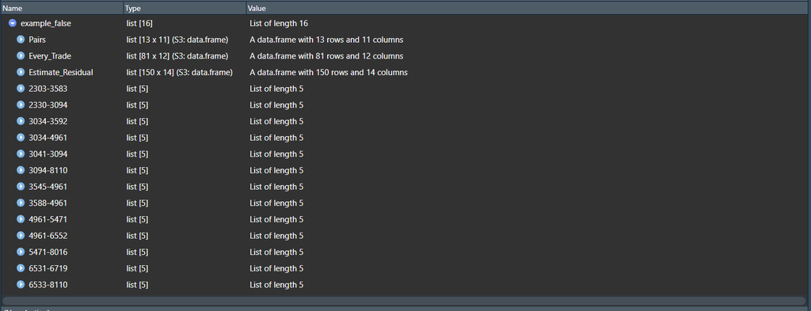

此圖為函數回傳的list檔案內容，因沒改變樣本篩選標準，所以一樣抓出相同的13筆配對樣本。

```r
example_false <- pair_trade(TEJ_data = semiconductor,
                               corr_coef = 0.95,estimate_days = 150,
                               ADF_p.value = 0.02,mean_type = "rolling",
                               sd_type = "rolling",Open = 2,Windows = 100,
                               Close = 1,Stop_loss = 5,Weight = "less",Rebalance = FALSE,
                     Plot_StopLoss = FALSE)
```

可以看到list裡有：

- $Pairs:$裡包含了每組配對的交易資訊，有兩股代號、相關係數、迴歸截距、迴歸係數、迴歸p.value、迴歸調整R_square、總交易次數、平均交易天數、所有交易的一般平均數報酬率、幾何平均數報酬率。  
  因為不重新估計迴歸，所以把一些配對樣本的資訊留在這裡，不放在各個配對裡的$List$了。

  | y_stock | x_stock | corr_coef | Intercept | beta | p.value | adj.r.squared | Transactions | Mean_Days | Return_AMean(%) | Return_GMean(%) |
  | --- | --- | --- | --- | --- | --- | --- | --- | --- | --- | --- |
  | 2303 | 3583 | 0.9524233 | -5.435804 | 0.6487381 | 0.0140178 | 0.9064825 | 2 | 40.00 | 1.767418 | 1.765029 |
  | 2330 | 3094 | 0.9527771 | 148.433832 | 12.9443124 | 0.0100000 | 0.9071611 | 5 | 24.40 | 2.118604 | 2.090406 |
  | 3034 | 3592 | 0.9512304 | 90.228995 | 0.6373223 | 0.0130521 | 0.9041962 | 5 | 24.40 | 2.632501 | 2.616654 |
  | 3034 | 4961 | 0.9585993 | 11.334541 | 2.0692212 | 0.0108484 | 0.9183647 | 5 | 9.20 | 2.386274 | 2.354420 |
  | 3041 | 3094 | 0.9595573 | -4.813853 | 1.1032537 | 0.0148592 | 0.9202147 | 4 | 41.75 | -3.648455 | -3.792868 |
  | 3094 | 8110 | 0.9535481 | 2.084362 | 1.9419145 | 0.0100000 | 0.9086409 | 3 | 25.33 | -1.820582 | -2.076333 |
  | 3545 | 4961 | 0.9707261 | -9.350922 | 0.7186792 | 0.0100000 | 0.9419194 | 1 | 134.00 | -7.388591 | -7.388591 |
  | 3588 | 4961 | 0.9550469 | -6.292089 | 0.6485530 | 0.0103500 | 0.9115208 | 3 | 36.00 | 4.434211 | 4.309004 |
  | 4961 | 5471 | 0.9549251 | -73.721639 | 3.3440036 | 0.0100000 | 0.9112865 | 2 | 52.50 | -1.208574 | -1.210498 |
  | 4961 | 6552 | 0.9627072 | -143.622204 | 6.9920129 | 0.0100000 | 0.9263105 | 2 | 30.00 | -7.914295 | -8.209528 |
  | 5471 | 8016 | 0.9656620 | 25.020045 | 0.2077351 | 0.0100000 | 0.9320470 | 2 | 73.50 | -4.666362 | -4.684611 |
  | 6531 | 6719 | 0.9714780 | 58.505013 | 0.4247070 | 0.0100000 | 0.9433896 | 2 | 45.00 | 1.262312 | 1.020184 |
  | 6533 | 8110 | 0.9710411 | -157.174048 | 33.4874905 | 0.0100000 | 0.9425351 | 3 | 53.33 | -5.598006 | -5.716345 |

- $Every-Trade:$同 Rebalance = TRUE。

  | 交易日期 | 交易型態 | 建or平倉 | 買入股 | 買入價 | 買入量 | 放空股 | 放空價 | 放空量 | 交易天數 | 報酬率% | 建倉成本(千) |
  | --- | --- | --- | --- | --- | --- | --- | --- | --- | --- | --- | --- |
  | 2022-08-19 | 收縮 | 建倉 | 買入 2303 | 42.8692 | 85 | 放空 3583 | 85.0050 | 43 | NA | NA | 8895 |
  | 2022-09-26 | 收縮 | 平倉 | 回補 3583 | 71.1816 | 43 | 賣出 2303 | 37.2347 | 85 | 38 | 1.0701929 | NA |
  | 2022-10-21 | 擴張 | 建倉 | 買入 3583 | 62.6205 | 13 | 放空 2303 | 39.4037 | 21 | NA | NA | 1560 |
  | 2022-12-02 | 擴張 | 平倉 | 回補 2303 | 45.2220 | 21 | 賣出 3583 | 75.8104 | 13 | 42 | 2.4646425 | NA |
  | 2023-04-25 | 收縮 | 建倉 | 買入 2303 | 48.8589 | 88 | 放空 3583 | 88.4813 | 49 | NA | NA | 9952 |
  | 2022-08-26 | 收縮 | 建倉 | 買入 2330 | 512.9141 | 1 | 放空 3094 | 29.9540 | 17 | NA | NA | 7878 |
  | 2022-09-07 | 收縮 | 平倉 | 回補 3094 | 27.8627 | 17 | 賣出 2330 | 474.8775 | 1 | 12 | -0.8836883 | NA |
  | 2022-09-12 | 收縮 | 建倉 | 買入 2330 | 488.1300 | 29 | 放空 3094 | 29.0434 | 490 | NA | NA | 216109 |
  | 2022-09-27 | 收縮 | 平倉 | 回補 3094 | 25.3199 | 490 | 賣出 2330 | 448.4397 | 29 | 15 | 1.8750189 | NA |
  | 2022-10-03 | 收縮 | 建倉 | 買入 2330 | 418.9327 | 5 | 放空 3094 | 25.2496 | 84 | NA | NA | 31798 |
  | 2022-11-14 | 收縮 | 平倉 | 回補 3094 | 25.8447 | 84 | 賣出 2330 | 446.5272 | 5 | 42 | 1.5442085 | NA |
  | 2023-01-16 | 擴張 | 建倉 | 買入 3094 | 24.7641 | 20 | 放空 2330 | 504.7188 | 1 | NA | NA | 950 |
  | 2023-02-16 | 擴張 | 平倉 | 回補 2330 | 527.9830 | 1 | 賣出 3094 | 29.3537 | 20 | 31 | 6.5244023 | NA |
  | 2023-04-20 | 收縮 | 建倉 | 買入 2330 | 513.2805 | 7 | 放空 3094 | 34.5085 | 102 | NA | NA | 47361 |
  | 2023-05-12 | 收縮 | 平倉 | 回補 3094 | 31.9623 | 102 | 賣出 2330 | 497.1042 | 7 | 22 | 1.5330776 | NA |
  | 2022-09-12 | 擴張 | 建倉 | 買入 3592 | 251.2242 | 27 | 放空 3034 | 265.1075 | 25 | NA | NA | 12758 |
  | 2022-09-19 | 擴張 | 平倉 | 回補 3034 | 250.2008 | 25 | 賣出 3592 | 252.6521 | 27 | 7 | 2.5734226 | NA |
  | 2022-10-13 | 擴張 | 建倉 | 買入 3592 | 201.8983 | 6 | 放空 3034 | 236.7580 | 5 | NA | NA | 2279 |
  | 2022-10-19 | 擴張 | 平倉 | 回補 3034 | 245.4814 | 5 | 賣出 3592 | 229.8111 | 6 | 6 | 4.7474297 | NA |
  | 2022-11-11 | 擴張 | 建倉 | 買入 3592 | 293.6089 | 30 | 放空 3034 | 303.6344 | 29 | NA | NA | 16746 |
  | 2022-11-17 | 擴張 | 平倉 | 回補 3034 | 308.5774 | 29 | 賣出 3592 | 325.1918 | 30 | 6 | 4.1217049 | NA |
  | 2022-12-08 | 擴張 | 建倉 | 買入 3592 | 301.7428 | 1 | 放空 3034 | 298.3775 | 1 | NA | NA | 571 |
  | 2022-12-26 | 擴張 | 平倉 | 回補 3034 | 305.2762 | 1 | 賣出 3592 | 310.0908 | 1 | 18 | -0.4014482 | NA |
  | 2022-12-28 | 擴張 | 建倉 | 買入 3592 | 304.1843 | 31 | 放空 3034 | 311.1935 | 30 | NA | NA | 17845 |
  | 2023-03-23 | 擴張 | 平倉 | 回補 3034 | 432.0954 | 30 | 賣出 3592 | 437.6719 | 31 | 85 | 2.1213944 | NA |
  | 2023-04-12 | 擴張 | 建倉 | 買入 3592 | 421.1241 | 23 | 放空 3034 | 457.1747 | 21 | NA | NA | 18340 |
  | 2022-12-27 | 擴張 | 建倉 | 買入 4961 | 122.4775 | 8 | 放空 3034 | 320.9498 | 3 | NA | NA | 1848 |
  | 2023-01-11 | 擴張 | 平倉 | 回補 3034 | 349.0637 | 3 | 賣出 4961 | 142.0491 | 8 | 15 | 3.2164603 | NA |
  | 2023-02-09 | 擴張 | 建倉 | 買入 4961 | 144.6184 | 39 | 放空 3034 | 385.5223 | 14 | NA | NA | 10506 |
  | 2023-02-20 | 擴張 | 平倉 | 回補 3034 | 408.2807 | 14 | 賣出 4961 | 172.3540 | 39 | 11 | 6.5636516 | NA |

  [output cut: 51 more lines]

- $Estimate.Residual:$同 Rebalance = TRUE，這裡就不show出來了。
- $\bf各組配對:$以第一組配對2303-3583為例，這組樣本完整交易了2次，第三次建倉了沒平倉。 因沒有重新估計，所以$List$裡不加上配對結束原因，一律把資料跑完。

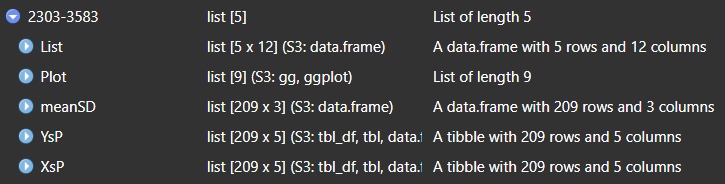

  包含了交易資訊、交易圖、每日對應的殘差平均數和標準差、兩股股價資料

  $meanSD$、$YsP$、$XsP$與Rebalance = TRUE一樣，這裡就不show出來了。
  - $List:$交易資訊，資料如同Every_Trade裡的資料。

    | 交易日期 | 交易型態 | 建or平倉 | 買入股 | 買入價 | 買入量 | 放空股 | 放空價 | 放空量 | 交易天數 | 報酬率% | 建倉成本(千) |
    | --- | --- | --- | --- | --- | --- | --- | --- | --- | --- | --- | --- |
    | 2022-08-19 | 收縮 | 建倉 | 買入 2303 | 42.8692 | 85 | 放空 3583 | 85.0050 | 43 | NA | NA | 8895 |
    | 2022-09-26 | 收縮 | 平倉 | 回補 3583 | 71.1816 | 43 | 賣出 2303 | 37.2347 | 85 | 38 | 1.070193 | NA |
    | 2022-10-21 | 擴張 | 建倉 | 買入 3583 | 62.6205 | 13 | 放空 2303 | 39.4037 | 21 | NA | NA | 1560 |
    | 2022-12-02 | 擴張 | 平倉 | 回補 2303 | 45.2220 | 21 | 賣出 3583 | 75.8104 | 13 | 42 | 2.464643 | NA |
    | 2023-04-25 | 收縮 | 建倉 | 買入 2303 | 48.8589 | 88 | 放空 3583 | 88.4813 | 49 | NA | NA | 9952 |

  - $Plot:$交易圖，標題有股票代碼、建倉平倉停損的標準差倍數，$mean(\epsilon)、sd(\epsilon)$的計算方式。 此範例資料為rolling、rolling且Plot_StopLoss = FALSE，所以建倉平倉標準不是直線且沒有畫出停損紅線。

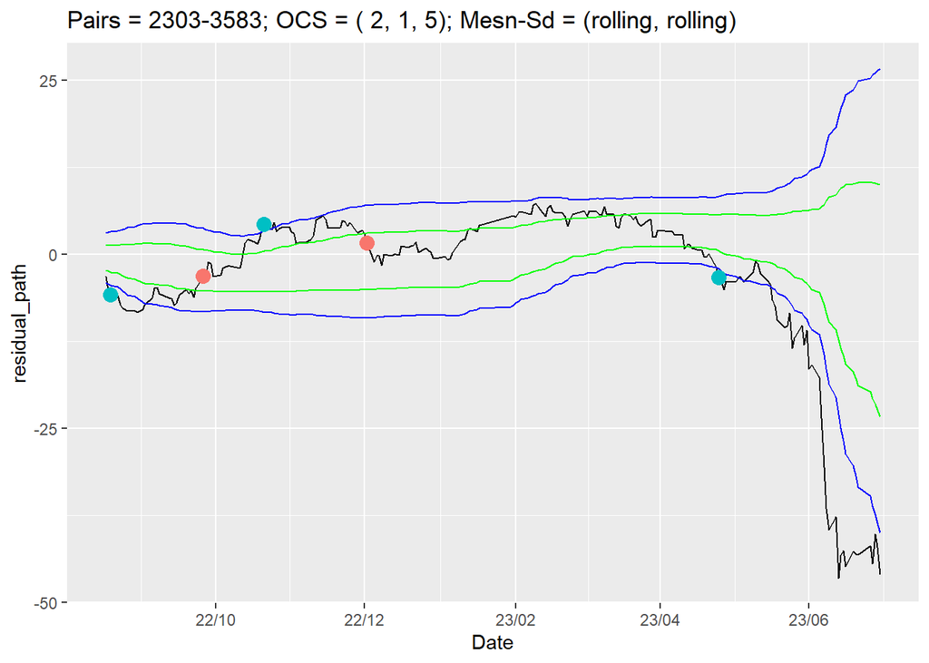

# 5. 注意事項

## 5.1 我沒發現的bug

可能有我沒發現的bug。

# 6. 結論與建議

## 6.1 結論

整個配對交易回測我大概是重7月開始寫的，但中間要論文meeting，且一邊寫一邊有新的想法加進來，所以寫了很久才完成，$ Rebalance = TRUE$ 的想法我碩一那時就有了，現在終於把他實現了，但報酬感覺沒有改善…  
我花了一點時間試了一些策略，發現不要設停損報酬會稍微好看一些，但會有滿多的未平倉配對樣本，把未平倉的圖打開會發現$ResidualPath$已經遠離了平倉標準，換句話說要不是認賠出場就是持續被套牢，這也很合理，畢竟我的回測資產是股票，股價本來就可能因實際營運情況大漲或大跌且回不去原本股價。  
以下面的策略為例，分為有停損組跟無停損組：

```r
with_stoploss <- pair_trade(TEJ_data = semiconductor,
                                       corr_coef = 0.95,estimate_days = 150,
                                       ADF_p.value = 0.02,mean_type = "fixed",
                                       sd_type = "rolling",Open = 2,Windows = 30,
                                       Close = 1,Stop_loss = 5,Weight = "less",Rebalance = TRUE,
                                       Plot_StopLoss = TRUE)
```

| y_stock | x_stock | Transactions | Mean_Days | Return_AMean(%) | Return_GMean(%) |
| --- | --- | --- | --- | --- | --- |
| 2303 | 3583 | 1 | 42.00 | 1.5020504 | 1.5020504 |
| 2330 | 3094 | 1 | 12.00 | -0.8836883 | -0.8836883 |
| 3034 | 3592 | 4 | 22.75 | 0.8800066 | 0.8571642 |
| 3034 | 4961 | 1 | 13.00 | 4.1567410 | 4.1567410 |
| 3041 | 3094 | 1 | 50.00 | -3.9059605 | -3.9059605 |
| 3094 | 8110 | 1 | 40.00 | 3.9351002 | 3.9351002 |
| 3545 | 4961 | 1 | 6.00 | 3.0966730 | 3.0966730 |
| 3588 | 4961 | 3 | 8.00 | 3.5924444 | 3.4874309 |
| 4961 | 5471 | 2 | 23.50 | -5.5357168 | -5.7890028 |
| 4961 | 6552 | 1 | 3.00 | 2.8884073 | 2.8884073 |
| 5471 | 8016 | 1 | 22.00 | 0.9761531 | 0.9761531 |
| 6531 | 6719 | 2 | 8.50 | 0.2438976 | 0.2284934 |
| 6533 | 8110 | 1 | 50.00 | -19.2145693 | -19.2145693 |

```r
without_stoploss <- pair_trade(TEJ_data = semiconductor,
                                       corr_coef = 0.95,estimate_days = 150,
                                       ADF_p.value = 0.02,mean_type = "fixed",
                                       sd_type = "rolling",Open = 2,Windows = 30,
                                       Close = 1,Stop_loss = 999,Weight = "less",Rebalance = TRUE,
                                       Plot_StopLoss = FALSE)
```

| y_stock | x_stock | Transactions | Mean_Days | Return_AMean(%) | Return_GMean(%) |
| --- | --- | --- | --- | --- | --- |
| 2303 | 3583 | 1 | 42.0 | 1.5020504 | 1.5020504 |
| 2330 | 3094 | 1 | 12.0 | -0.8836883 | -0.8836883 |
| 3034 | 3592 | 2 | 15.0 | 2.7331299 | 2.7329957 |
| 3034 | 4961 | 1 | 13.0 | 4.1567410 | 4.1567410 |
| 3041 | 3094 | 1 | 130.0 | 1.0912805 | 1.0912805 |
| 3094 | 8110 | 1 | 40.0 | 3.9351002 | 3.9351002 |
| 3545 | 4961 | 1 | 6.0 | 3.0966730 | 3.0966730 |
| 3588 | 4961 | 2 | 8.5 | 6.1034513 | 6.0371585 |
| 4961 | 5471 | 2 | 36.5 | 0.6134721 | 0.6105732 |
| 4961 | 6552 | 1 | 3.0 | 2.8884073 | 2.8884073 |
| 5471 | 8016 | NA | NA | NA | NA |
| 6531 | 6719 | 2 | 8.5 | 0.2438976 | 0.2284934 |
| 6533 | 8110 | NA | NA | NA | NA |

以6533-8110配對來看

- 有停損時，$ResidualPath(\epsilon_r)$碰到停損於是報酬為$-19.2145693 \%$。
- 無停損時，$ResidualPath(\epsilon_r)$跑出建倉標準且一去不復返，所以沒有完成交易，換句話說被套牢了。

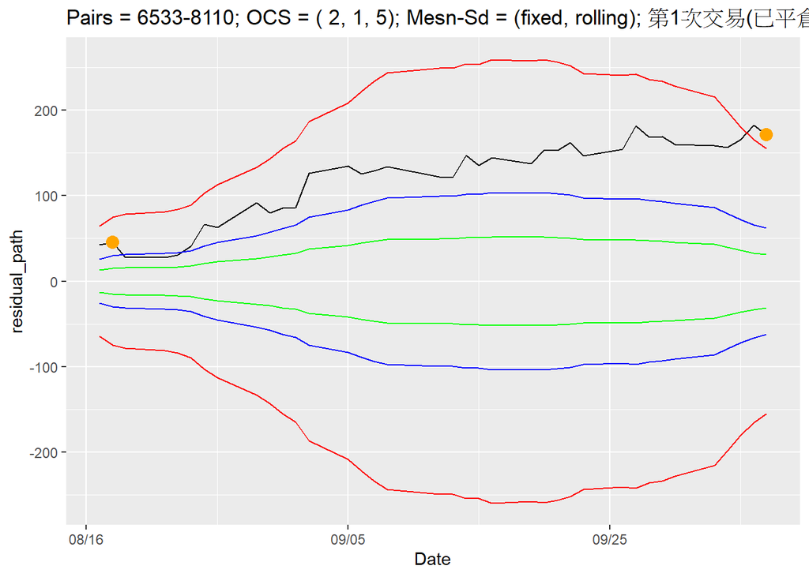

```r
with_stoploss$`6533-8110`$Plot$第1次交易_圖
```

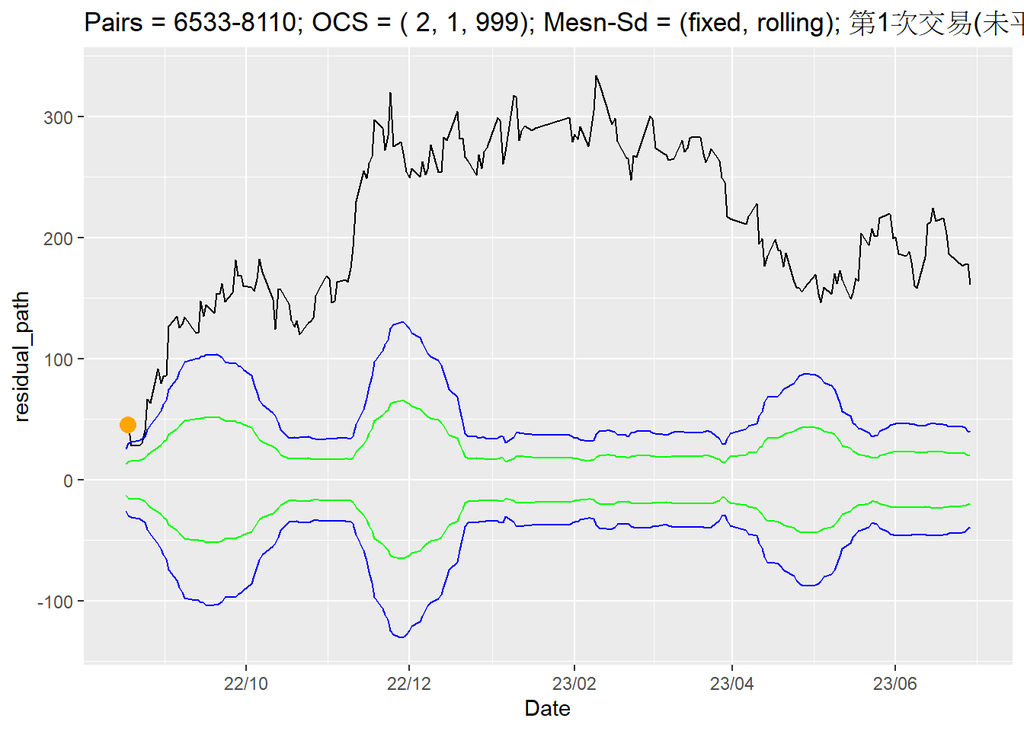

```r
without_stoploss$`6533-8110`$Plot$第1次交易_圖
```

## 6.2 建議

如同上面結論所述，股票不適合拿來做配對交易，我也有在網路上看到有人有相同想法，我想比較適合的標的資產應該是期貨吧？  
說來慚愧，我的計量不太好，如果我理解沒有錯，配對交易基本上是依靠統計中的$\bf共整合(Cointegration)$現象，也就是多條時間序列在線性組合後成為了一個定態的時間序列，我的回測(共整合)方法類似$\color{red}{Engle-Granger\quad test}$，但不完全一樣(畢竟是我自己寫的，簡略很多)，有另一個共整合檢定$\color{red}{Johansen \quad test}$，可以有多個而不是2個時間序列資料去找出線性組合為定態的$ResidualPath$，我想有多個資產組合起來，可能會組合出更穩定的$ResidualPath$達到想要的結果，或者透過一些機器學習的方法，找出如何有效預測未來的$ResidualPath$也保持Stationary(此篇策略為檢測估計期殘差為定態後，直接納入樣本去交易)，這就留給未來的我去試了。  
總之，感謝你看到這裡，終於寫完了當初的想法，如果你有興趣自己試試看，我會把完整程式碼放在另外的Rmarkdown檔案，範例的股價資料也會一起放在Google雲端，可以下載來自己試試看，感謝你看到這。  
2023/10/18 22:11